# examples_1205

Amelia will use 156 feet of fence to build a rectangular enclosure for her dog. Amelia will build the enclosure next to a very long barn, so she'll only use the fencing for 3 of the sides of the rectangle.

Let $x$ represent the length of fence perpendicular to the barn, and let $y$ represent the length of fence parallel to the barn.

She wants to give her dog as much area as possible. Find the value of $x$ that maximizes the area.

The total length of fence is 156 feet. There are 2 sides with lengths of $x$ and one side with a length of $y$.

$$2x+y~=~156$$

Solve for $y$.

$$y~=~156-2x$$

Write an equation for the area. A rectangular area equals the length times the width.

$$A~=~xy$$

Substitute $156-2x$ in place of $y$ to get area in terms of only $x$.

$$A~=~x(156-2x)$$

From here, we can expand into standard form, and use the formula $h=\frac{-b}{2a}$ to find the vertex. Expand into standard form.

You can graph $A$ versus $x$ and get a downwards facing parabola.

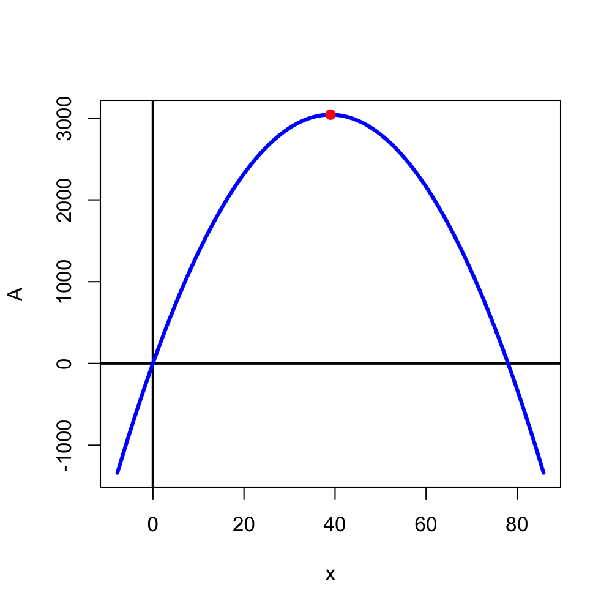

Now, remember the vertex (in this case the maximum) occurs when $x=\frac{-b}{2a}$.

So, the area is maximized when $x=39$ feet and $y=78$ feet.

Amelia will use 76 feet of fence to build a rectangular enclosure for her dog. Amelia will build the enclosure next to a very long barn, so she'll only use the fencing for 3 of the sides of the rectangle.

Let $x$ represent the length of fence perpendicular to the barn, and let $y$ represent the length of fence parallel to the barn.

She wants to give her dog as much area as possible. Find the value of $x$ that maximizes the area.

The total length of fence is 76 feet. There are 2 sides with lengths of $x$ and one side with a length of $y$.

$$2x+y~=~76$$

Solve for $y$.

$$y~=~76-2x$$

Write an equation for the area. A rectangular area equals the length times the width.

$$A~=~xy$$

Substitute $76-2x$ in place of $y$ to get area in terms of only $x$.

$$A~=~x(76-2x)$$

From here, we can expand into standard form, and use the formula $h=\frac{-b}{2a}$ to find the vertex. Expand into standard form.

You can graph $A$ versus $x$ and get a downwards facing parabola.

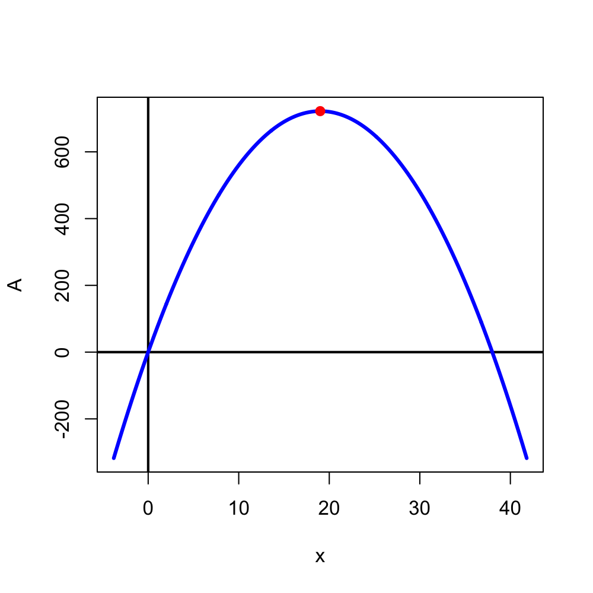

Now, remember the vertex (in this case the maximum) occurs when $x=\frac{-b}{2a}$.

So, the area is maximized when $x=19$ feet and $y=38$ feet.

Amelia will use 96 feet of fence to build a rectangular enclosure for her dog. Amelia will build the enclosure next to a very long barn, so she'll only use the fencing for 3 of the sides of the rectangle.

Let $x$ represent the length of fence perpendicular to the barn, and let $y$ represent the length of fence parallel to the barn.

She wants to give her dog as much area as possible. Find the value of $x$ that maximizes the area.

The total length of fence is 96 feet. There are 2 sides with lengths of $x$ and one side with a length of $y$.

$$2x+y~=~96$$

Solve for $y$.

$$y~=~96-2x$$

Write an equation for the area. A rectangular area equals the length times the width.

$$A~=~xy$$

Substitute $96-2x$ in place of $y$ to get area in terms of only $x$.

$$A~=~x(96-2x)$$

From here, we can expand into standard form, and use the formula $h=\frac{-b}{2a}$ to find the vertex. Expand into standard form.

You can graph $A$ versus $x$ and get a downwards facing parabola.

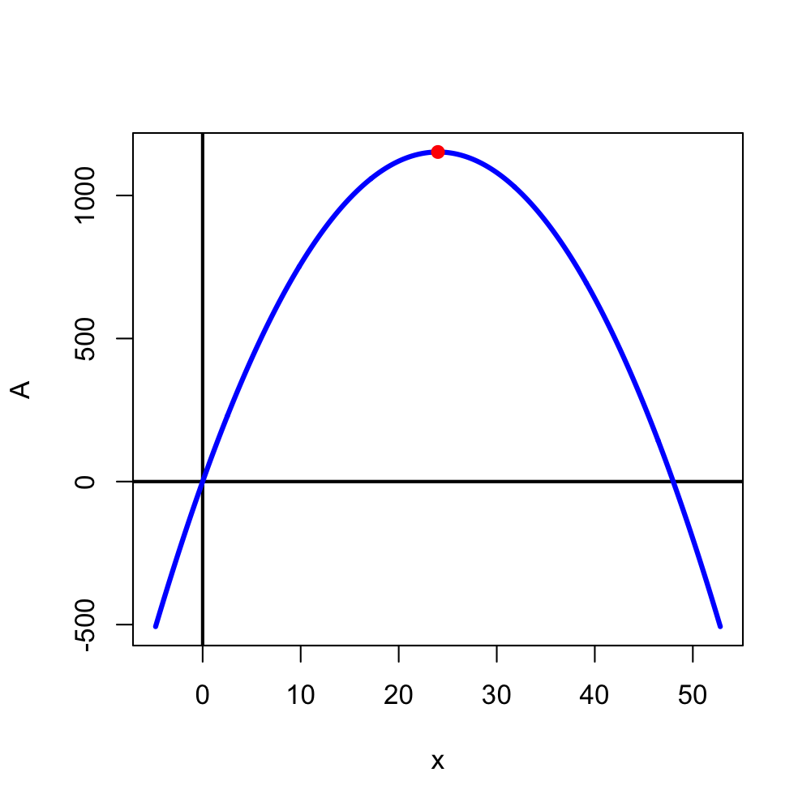

Now, remember the vertex (in this case the maximum) occurs when $x=\frac{-b}{2a}$.

So, the area is maximized when $x=24$ feet and $y=48$ feet.

Amelia will use 40 feet of fence to build a rectangular enclosure for her dog. Amelia will build the enclosure next to a very long barn, so she'll only use the fencing for 3 of the sides of the rectangle.

Let $x$ represent the length of fence perpendicular to the barn, and let $y$ represent the length of fence parallel to the barn.

She wants to give her dog as much area as possible. Find the value of $x$ that maximizes the area.

The total length of fence is 40 feet. There are 2 sides with lengths of $x$ and one side with a length of $y$.

$$2x+y~=~40$$

Solve for $y$.

$$y~=~40-2x$$

Write an equation for the area. A rectangular area equals the length times the width.

$$A~=~xy$$

Substitute $40-2x$ in place of $y$ to get area in terms of only $x$.

$$A~=~x(40-2x)$$

From here, we can expand into standard form, and use the formula $h=\frac{-b}{2a}$ to find the vertex. Expand into standard form.

You can graph $A$ versus $x$ and get a downwards facing parabola.

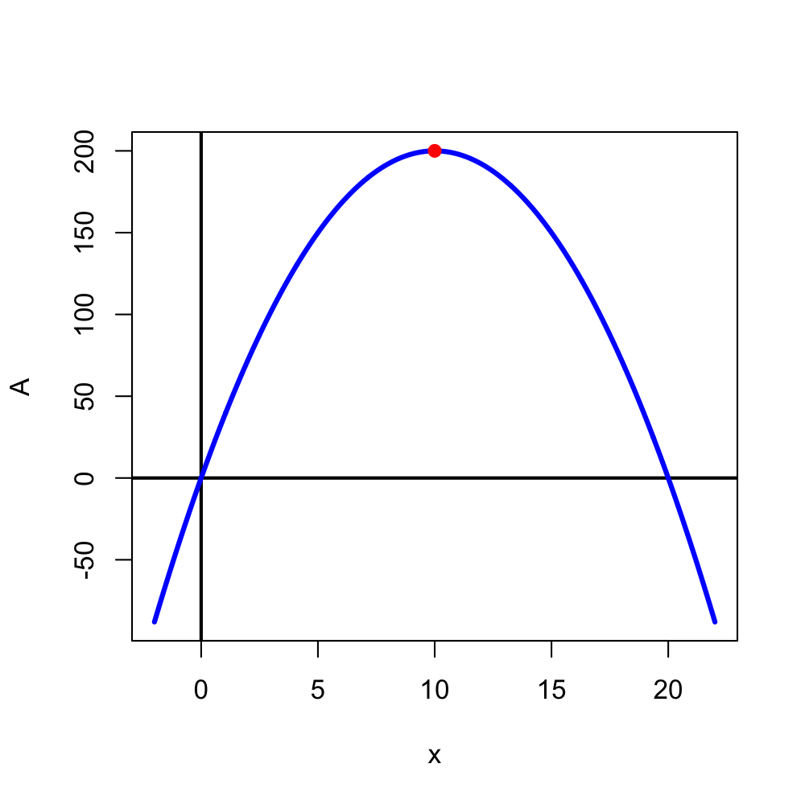

Now, remember the vertex (in this case the maximum) occurs when $x=\frac{-b}{2a}$.

So, the area is maximized when $x=10$ feet and $y=20$ feet.

Amelia will use 64 feet of fence to build a rectangular enclosure for her dog. Amelia will build the enclosure next to a very long barn, so she'll only use the fencing for 3 of the sides of the rectangle.

Let $x$ represent the length of fence perpendicular to the barn, and let $y$ represent the length of fence parallel to the barn.

She wants to give her dog as much area as possible. Find the value of $x$ that maximizes the area.

The total length of fence is 64 feet. There are 2 sides with lengths of $x$ and one side with a length of $y$.

$$2x+y~=~64$$

Solve for $y$.

$$y~=~64-2x$$

Write an equation for the area. A rectangular area equals the length times the width.

$$A~=~xy$$

Substitute $64-2x$ in place of $y$ to get area in terms of only $x$.

$$A~=~x(64-2x)$$

From here, we can expand into standard form, and use the formula $h=\frac{-b}{2a}$ to find the vertex. Expand into standard form.

You can graph $A$ versus $x$ and get a downwards facing parabola.

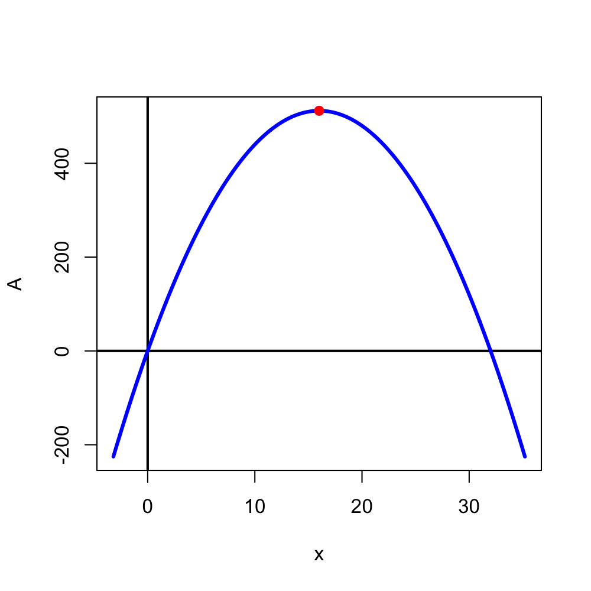

Now, remember the vertex (in this case the maximum) occurs when $x=\frac{-b}{2a}$.

So, the area is maximized when $x=16$ feet and $y=32$ feet.

Amelia will use 140 feet of fence to build a rectangular enclosure for her dog. Amelia will build the enclosure next to a very long barn, so she'll only use the fencing for 3 of the sides of the rectangle.

Let $x$ represent the length of fence perpendicular to the barn, and let $y$ represent the length of fence parallel to the barn.

She wants to give her dog as much area as possible. Find the value of $x$ that maximizes the area.

The total length of fence is 140 feet. There are 2 sides with lengths of $x$ and one side with a length of $y$.

$$2x+y~=~140$$

Solve for $y$.

$$y~=~140-2x$$

Write an equation for the area. A rectangular area equals the length times the width.

$$A~=~xy$$

Substitute $140-2x$ in place of $y$ to get area in terms of only $x$.

$$A~=~x(140-2x)$$

From here, we can expand into standard form, and use the formula $h=\frac{-b}{2a}$ to find the vertex. Expand into standard form.

You can graph $A$ versus $x$ and get a downwards facing parabola.

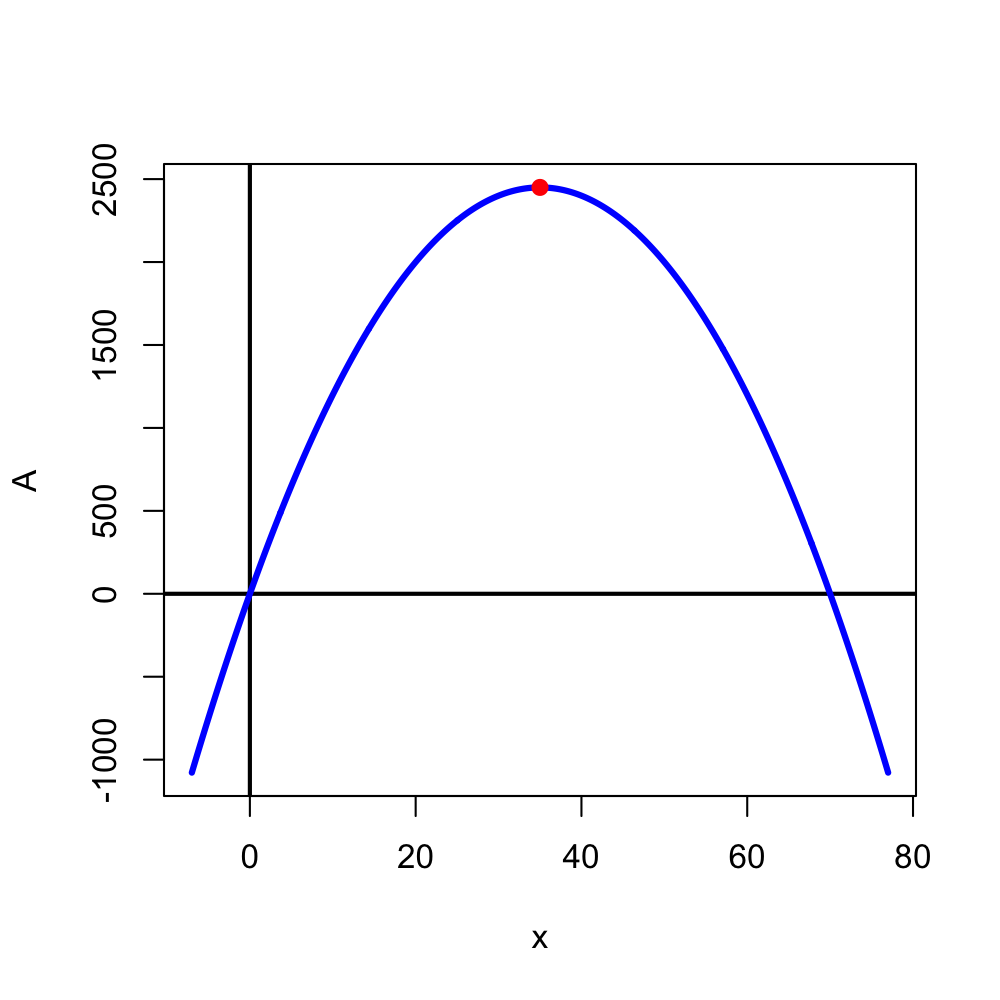

Now, remember the vertex (in this case the maximum) occurs when $x=\frac{-b}{2a}$.

So, the area is maximized when $x=35$ feet and $y=70$ feet.

Amelia will use 72 feet of fence to build a rectangular enclosure for her dog. Amelia will build the enclosure next to a very long barn, so she'll only use the fencing for 3 of the sides of the rectangle.

Let $x$ represent the length of fence perpendicular to the barn, and let $y$ represent the length of fence parallel to the barn.

She wants to give her dog as much area as possible. Find the value of $x$ that maximizes the area.

The total length of fence is 72 feet. There are 2 sides with lengths of $x$ and one side with a length of $y$.

$$2x+y~=~72$$

Solve for $y$.

$$y~=~72-2x$$

Write an equation for the area. A rectangular area equals the length times the width.

$$A~=~xy$$

Substitute $72-2x$ in place of $y$ to get area in terms of only $x$.

$$A~=~x(72-2x)$$

From here, we can expand into standard form, and use the formula $h=\frac{-b}{2a}$ to find the vertex. Expand into standard form.

You can graph $A$ versus $x$ and get a downwards facing parabola.

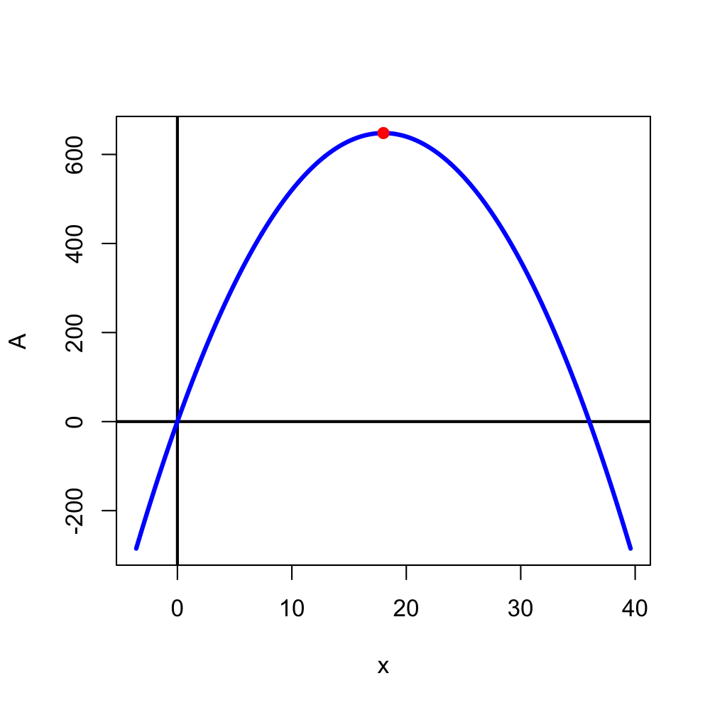

Now, remember the vertex (in this case the maximum) occurs when $x=\frac{-b}{2a}$.

So, the area is maximized when $x=18$ feet and $y=36$ feet.

Amelia will use 68 feet of fence to build a rectangular enclosure for her dog. Amelia will build the enclosure next to a very long barn, so she'll only use the fencing for 3 of the sides of the rectangle.

Let $x$ represent the length of fence perpendicular to the barn, and let $y$ represent the length of fence parallel to the barn.

She wants to give her dog as much area as possible. Find the value of $x$ that maximizes the area.

The total length of fence is 68 feet. There are 2 sides with lengths of $x$ and one side with a length of $y$.

$$2x+y~=~68$$

Solve for $y$.

$$y~=~68-2x$$

Write an equation for the area. A rectangular area equals the length times the width.

$$A~=~xy$$

Substitute $68-2x$ in place of $y$ to get area in terms of only $x$.

$$A~=~x(68-2x)$$

From here, we can expand into standard form, and use the formula $h=\frac{-b}{2a}$ to find the vertex. Expand into standard form.

You can graph $A$ versus $x$ and get a downwards facing parabola.

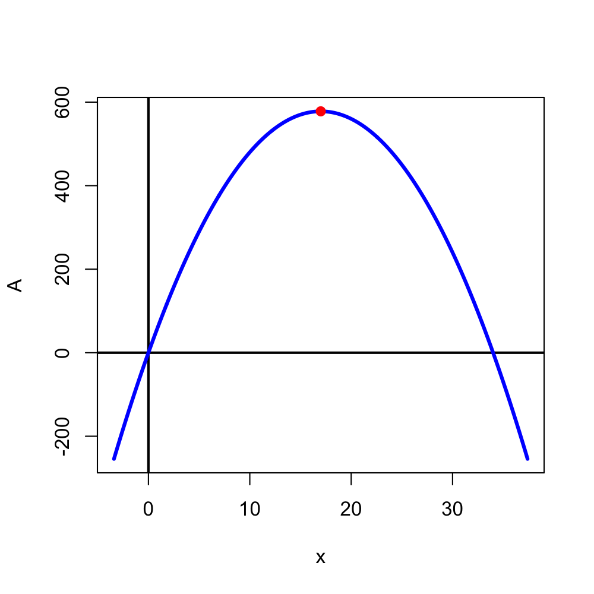

Now, remember the vertex (in this case the maximum) occurs when $x=\frac{-b}{2a}$.

So, the area is maximized when $x=17$ feet and $y=34$ feet.

Amelia wants to maximize the total area of the enclosures. Find the value of $x$ that maximizes the area.

The total area is simply the product of $x$ and $y$.

$$A~=~xy$$

The total length of fence is 320 feet. Notice for 9 enclosures, we need 10 lengths of $x$.

$$320~=~10x+y$$

Solve this equation for $y$ by subtracting $10x$ from both sides.

$$320-10x~=~y$$

Substitute $320-10x$ for $y$ in the area equation.

$$A~=~x\cdot(320-10x)$$

Distribute.

$$A~=~320x-10x^2$$

Put quadratic expression in standard order.

$$A~=~-10x^2+320x$$

If you draw a graph of $A$ versus $x$, you'll get a parabola.

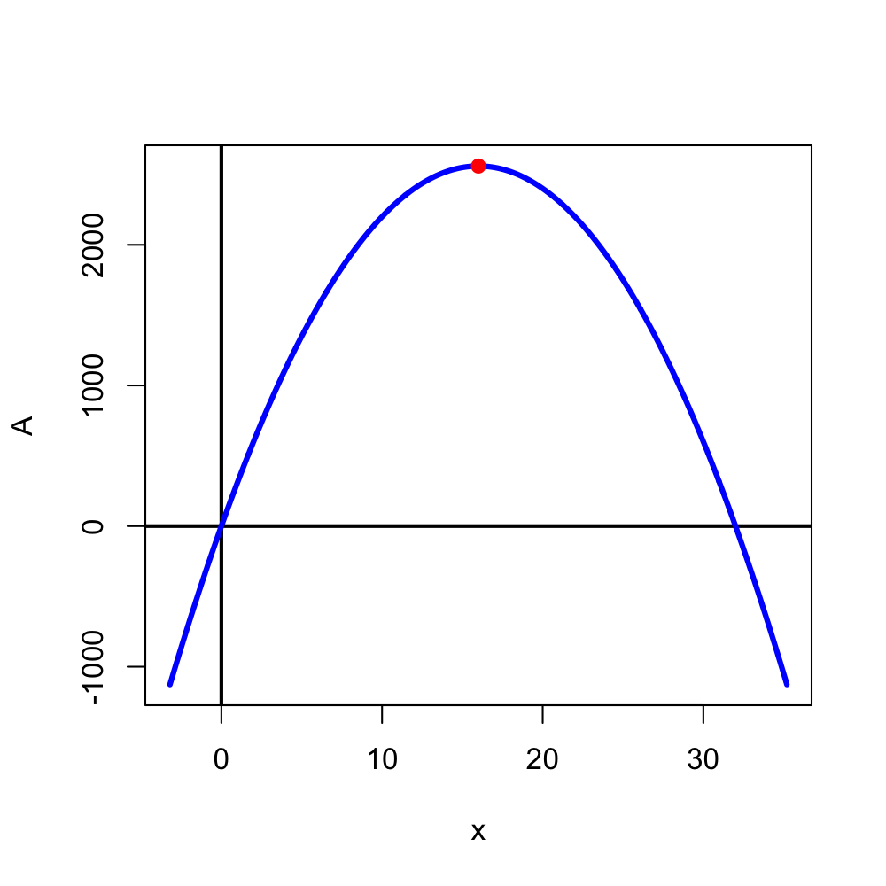

Notice, the maximum area occurs at the parabola's vertex. So, we can use $h=\frac{-b}{2a}$ to find the optimal $x$ value.

$$x_{\text{optimal}}~=~\frac{-b}{2a}$$

$$x_{\text{optimal}}~=~\frac{-(320)}{2(-10)}$$

$$x_{\text{optimal}}~=~16$$

Amelia wants to maximize the total area of the enclosures. Find the value of $x$ that maximizes the area.

The total area is simply the product of $x$ and $y$.

$$A~=~xy$$

The total length of fence is 600 feet. Notice for 9 enclosures, we need 10 lengths of $x$.

$$600~=~10x+y$$

Solve this equation for $y$ by subtracting $10x$ from both sides.

$$600-10x~=~y$$

Substitute $600-10x$ for $y$ in the area equation.

$$A~=~x\cdot(600-10x)$$

Distribute.

$$A~=~600x-10x^2$$

Put quadratic expression in standard order.

$$A~=~-10x^2+600x$$

If you draw a graph of $A$ versus $x$, you'll get a parabola.

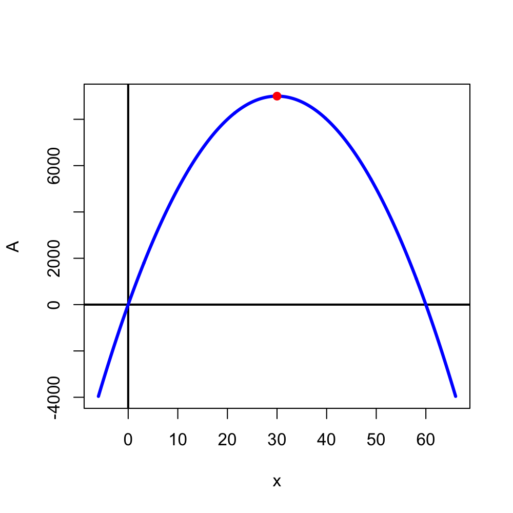

Notice, the maximum area occurs at the parabola's vertex. So, we can use $h=\frac{-b}{2a}$ to find the optimal $x$ value.

$$x_{\text{optimal}}~=~\frac{-b}{2a}$$

$$x_{\text{optimal}}~=~\frac{-(600)}{2(-10)}$$

$$x_{\text{optimal}}~=~30$$

Amelia wants to maximize the total area of the enclosures. Find the value of $x$ that maximizes the area.

The total area is simply the product of $x$ and $y$.

$$A~=~xy$$

The total length of fence is 260 feet. Notice for 9 enclosures, we need 10 lengths of $x$.

$$260~=~10x+y$$

Solve this equation for $y$ by subtracting $10x$ from both sides.

$$260-10x~=~y$$

Substitute $260-10x$ for $y$ in the area equation.

$$A~=~x\cdot(260-10x)$$

Distribute.

$$A~=~260x-10x^2$$

Put quadratic expression in standard order.

$$A~=~-10x^2+260x$$

If you draw a graph of $A$ versus $x$, you'll get a parabola.

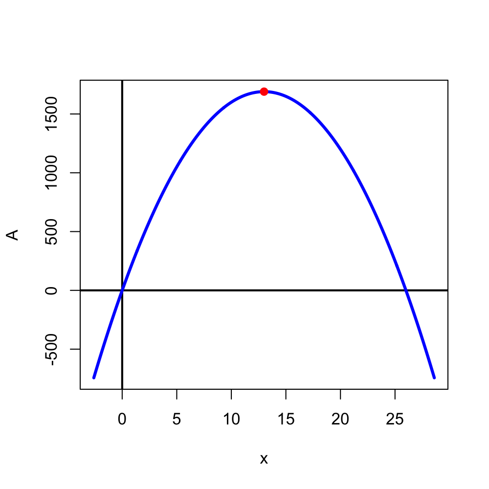

Notice, the maximum area occurs at the parabola's vertex. So, we can use $h=\frac{-b}{2a}$ to find the optimal $x$ value.

$$x_{\text{optimal}}~=~\frac{-b}{2a}$$

$$x_{\text{optimal}}~=~\frac{-(260)}{2(-10)}$$

$$x_{\text{optimal}}~=~13$$

Amelia wants to maximize the total area of the enclosures. Find the value of $x$ that maximizes the area.

The total area is simply the product of $x$ and $y$.

$$A~=~xy$$

The total length of fence is 280 feet. Notice for 9 enclosures, we need 10 lengths of $x$.

$$280~=~10x+y$$

Solve this equation for $y$ by subtracting $10x$ from both sides.

$$280-10x~=~y$$

Substitute $280-10x$ for $y$ in the area equation.

$$A~=~x\cdot(280-10x)$$

Distribute.

$$A~=~280x-10x^2$$

Put quadratic expression in standard order.

$$A~=~-10x^2+280x$$

If you draw a graph of $A$ versus $x$, you'll get a parabola.

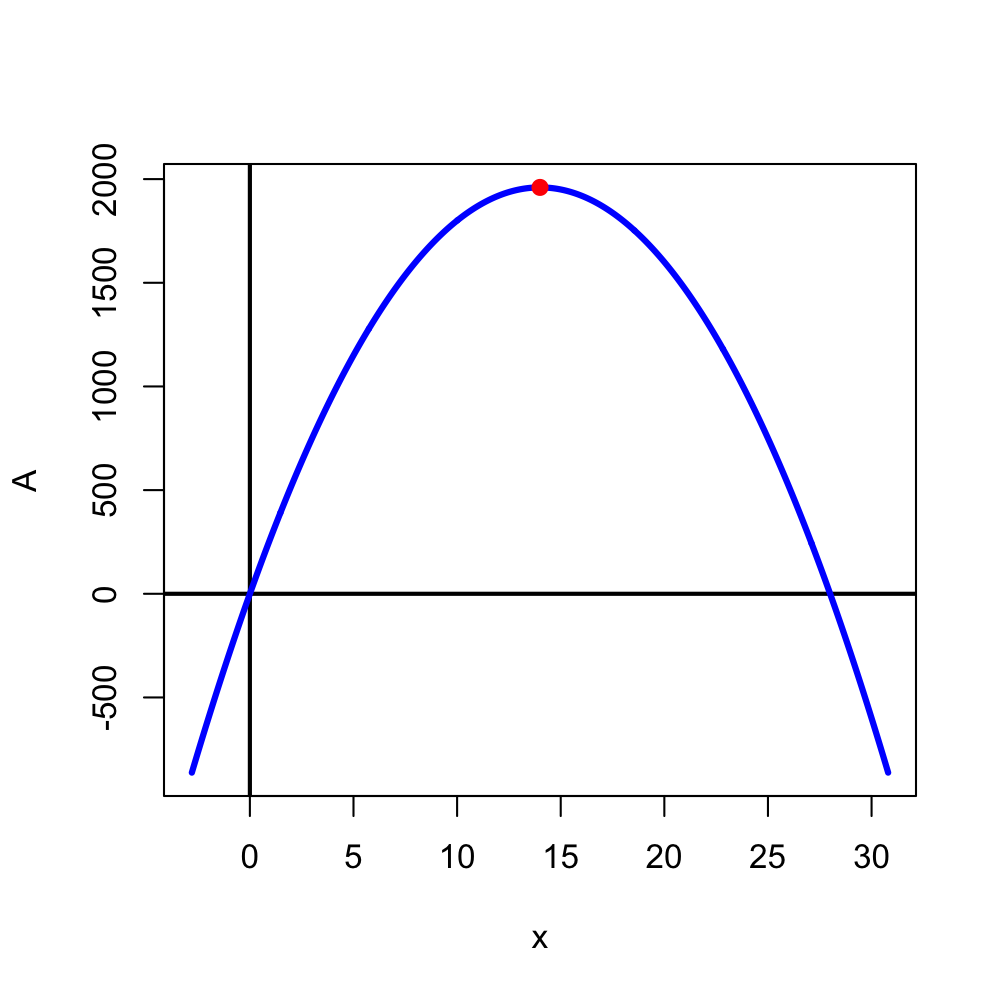

Notice, the maximum area occurs at the parabola's vertex. So, we can use $h=\frac{-b}{2a}$ to find the optimal $x$ value.

$$x_{\text{optimal}}~=~\frac{-b}{2a}$$

$$x_{\text{optimal}}~=~\frac{-(280)}{2(-10)}$$

$$x_{\text{optimal}}~=~14$$

Amelia wants to maximize the total area of the enclosures. Find the value of $x$ that maximizes the area.

The total area is simply the product of $x$ and $y$.

$$A~=~xy$$

The total length of fence is 640 feet. Notice for 9 enclosures, we need 10 lengths of $x$.

$$640~=~10x+y$$

Solve this equation for $y$ by subtracting $10x$ from both sides.

$$640-10x~=~y$$

Substitute $640-10x$ for $y$ in the area equation.

$$A~=~x\cdot(640-10x)$$

Distribute.

$$A~=~640x-10x^2$$

Put quadratic expression in standard order.

$$A~=~-10x^2+640x$$

If you draw a graph of $A$ versus $x$, you'll get a parabola.

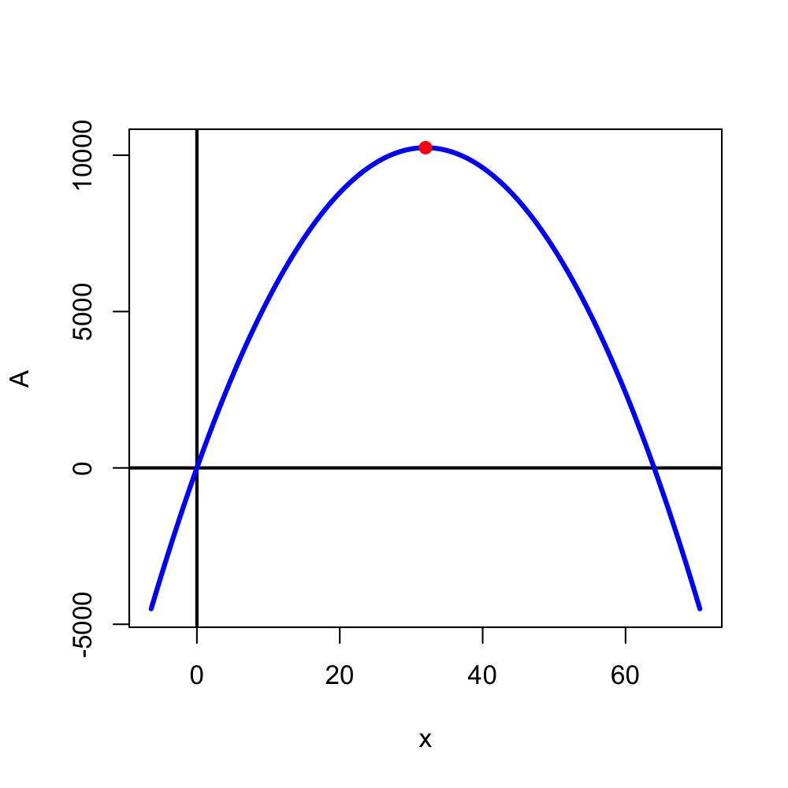

Notice, the maximum area occurs at the parabola's vertex. So, we can use $h=\frac{-b}{2a}$ to find the optimal $x$ value.

$$x_{\text{optimal}}~=~\frac{-b}{2a}$$

$$x_{\text{optimal}}~=~\frac{-(640)}{2(-10)}$$

$$x_{\text{optimal}}~=~32$$

Amelia wants to maximize the total area of the enclosures. Find the value of $x$ that maximizes the area.

The total area is simply the product of $x$ and $y$.

$$A~=~xy$$

The total length of fence is 380 feet. Notice for 9 enclosures, we need 10 lengths of $x$.

$$380~=~10x+y$$

Solve this equation for $y$ by subtracting $10x$ from both sides.

$$380-10x~=~y$$

Substitute $380-10x$ for $y$ in the area equation.

$$A~=~x\cdot(380-10x)$$

Distribute.

$$A~=~380x-10x^2$$

Put quadratic expression in standard order.

$$A~=~-10x^2+380x$$

If you draw a graph of $A$ versus $x$, you'll get a parabola.

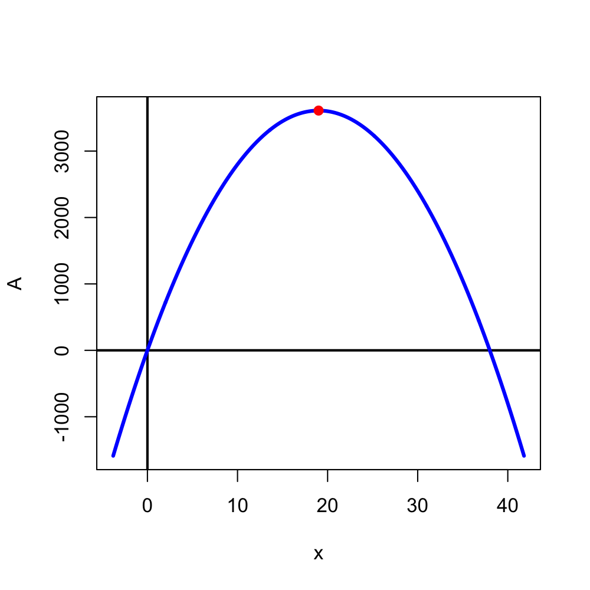

Notice, the maximum area occurs at the parabola's vertex. So, we can use $h=\frac{-b}{2a}$ to find the optimal $x$ value.

$$x_{\text{optimal}}~=~\frac{-b}{2a}$$

$$x_{\text{optimal}}~=~\frac{-(380)}{2(-10)}$$

$$x_{\text{optimal}}~=~19$$

Amelia wants to maximize the total area of the enclosures. Find the value of $x$ that maximizes the area.

The total area is simply the product of $x$ and $y$.

$$A~=~xy$$

The total length of fence is 220 feet. Notice for 9 enclosures, we need 10 lengths of $x$.

$$220~=~10x+y$$

Solve this equation for $y$ by subtracting $10x$ from both sides.

$$220-10x~=~y$$

Substitute $220-10x$ for $y$ in the area equation.

$$A~=~x\cdot(220-10x)$$

Distribute.

$$A~=~220x-10x^2$$

Put quadratic expression in standard order.

$$A~=~-10x^2+220x$$

If you draw a graph of $A$ versus $x$, you'll get a parabola.

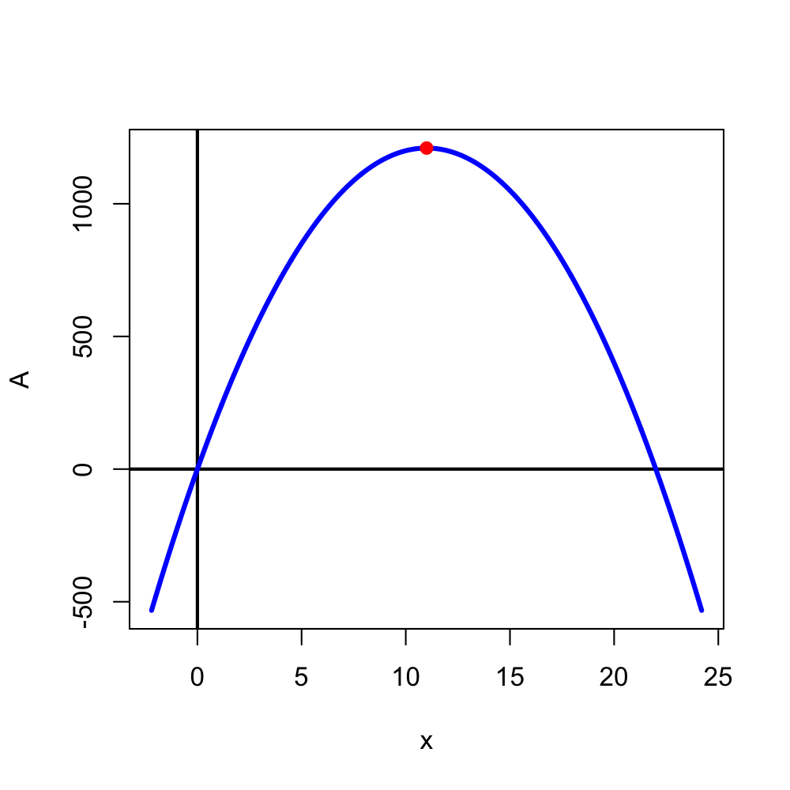

Notice, the maximum area occurs at the parabola's vertex. So, we can use $h=\frac{-b}{2a}$ to find the optimal $x$ value.

$$x_{\text{optimal}}~=~\frac{-b}{2a}$$

$$x_{\text{optimal}}~=~\frac{-(220)}{2(-10)}$$

$$x_{\text{optimal}}~=~11$$

Amelia wants to maximize the total area of the enclosures. Find the value of $x$ that maximizes the area.

The total area is simply the product of $x$ and $y$.

$$A~=~xy$$

The total length of fence is 680 feet. Notice for 9 enclosures, we need 10 lengths of $x$.

$$680~=~10x+y$$

Solve this equation for $y$ by subtracting $10x$ from both sides.

$$680-10x~=~y$$

Substitute $680-10x$ for $y$ in the area equation.

$$A~=~x\cdot(680-10x)$$

Distribute.

$$A~=~680x-10x^2$$

Put quadratic expression in standard order.

$$A~=~-10x^2+680x$$

If you draw a graph of $A$ versus $x$, you'll get a parabola.

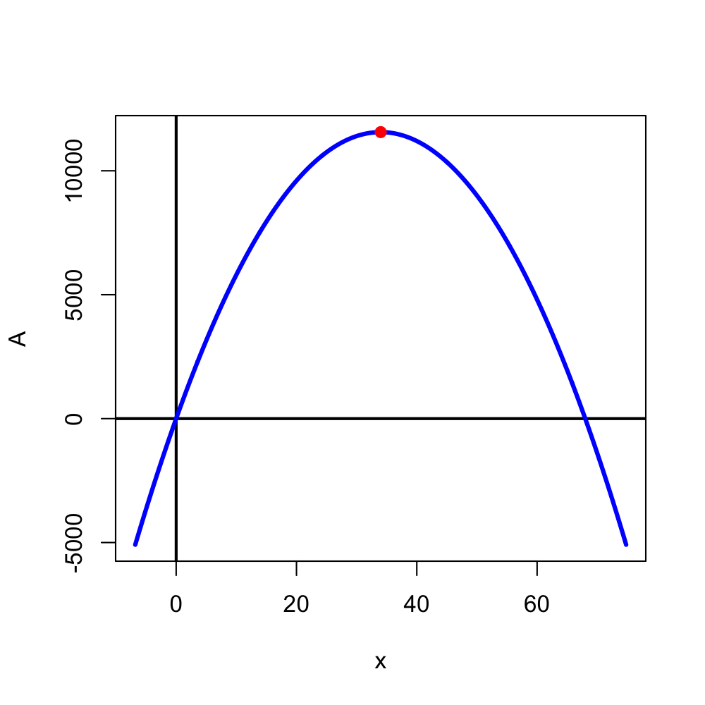

Notice, the maximum area occurs at the parabola's vertex. So, we can use $h=\frac{-b}{2a}$ to find the optimal $x$ value.

$$x_{\text{optimal}}~=~\frac{-b}{2a}$$

$$x_{\text{optimal}}~=~\frac{-(680)}{2(-10)}$$

$$x_{\text{optimal}}~=~34$$